# Sweep regions

Extract swept regions around peaks

```python
import re, os, sys, pickle, pickle, subprocess, bisect, random
from pathlib import Path
import numpy
import pandas
from pandas import DataFrame, Series

import scipy

from ete3 import Tree
from scipy.cluster.hierarchy import dendrogram, linkage

import pyfaidx

# my own libaries
from ChromosomeWindows import window
import genominterv

numpy.random.seed(7)
random.seed(7)
```

```python
import re, os, sys, pickle, math, collections, random
from pathlib import Path
import numpy
import pandas
from pandas import DataFrame
from ete3 import Tree
from scipy.cluster.hierarchy import dendrogram, linkage
import subprocess
import bisect
import pyfaidx
```

Plotting setup:

```python
%matplotlib inline

# Make inline plots vector graphics instead of raster graphics
from IPython.display import set_matplotlib_formats
set_matplotlib_formats('retina', 'png')

import matplotlib
import matplotlib.pyplot as plt
from matplotlib.colors import ListedColormap
from matplotlib.patches import Rectangle
from matplotlib.lines import Line2D

from mpl_toolkits.basemap import Basemap
#matplotlib.rcParams['figure.figsize'] = (20.0, 10.0)

import mpld3

import seaborn as sns
sns.set() # sets seaborn default "prettyness:
sns.set_style("whitegrid")
sns.set_context("paper")

# lowess for plotting
from statsmodels.nonparametric.smoothers_lowess import lowess

set1 = {'red': '#e41a1c', 'blue': '#377eb8', 'green': '#4daf4a',
        'purple': '#984ea3', 'orange': '#ff7f00',
        'yellow': '#ffff33', 'brown': '#a65628'}
```

Ignore deprecation warnings from mainly seaborn:

```python
# silence deprecation warnings (lots from seaborn)
import warnings
warnings.filterwarnings("ignore", category=DeprecationWarning)
warnings.filterwarnings("ignore", category=numpy.VisibleDeprecationWarning)
warnings.filterwarnings("ignore",category=matplotlib.cbook.mplDeprecation)
```

### Analysis dirs

```python
root_dir = Path(os.environ['HOME'], 'simons/faststorage/people/kmt')
meta_data_dir = Path(os.environ['HOME'], 'simons/faststorage/data/metadata')
steps_dir = root_dir / 'steps'
argweaver_dir = steps_dir / 'argweaver/output'
results_dir = root_dir / 'results'
figures_dir = root_dir / 'figures'
data_dir = root_dir / 'data'
pi_dir = steps_dir / 'pi_stores'
dist_dir = steps_dir / 'dist_stores'
#pi_dir = root_dir / 'old_pi_stores'
male_x_haploid_dir = steps_dir / 'male_x_haploids'

reference_genome_file = Path('/home', 'kmt', 'simons',
                        'faststorage', 'cteam_lite_public3', 'FullyPublic', 'Href.fa')
```

Import variables global to the entire analysis:

```python
import analysis_globals
```

Local code in the scripts dir on the cluster:

```python
scripts_dir = root_dir / 'scripts'
if str(scripts_dir) not in sys.path:
    sys.path.append(str(scripts_dir))

import simons_meta_data
import hg19_chrom_sizes

from toggle_code_and_errors import toggle_code_html, toggle_errors_html
```

## Convenience functions

```python
def silent_nanmean(x):
    with warnings.catch_warnings():
        warnings.simplefilter("ignore")
        return numpy.nanmean(x)

def ident_scalar(s):
    x = s.unique()
    assert(len(x)) == 1
    return x[0]

def flatten_column_index(df):
    df.columns = ['_'.join(col).strip() for col in df.columns.values]
```

```python
import time
class Timer:
    def __enter__(self):
        self.start = time.clock()
        return self

    def __exit__(self, *args):
        self.end = time.clock()
        self.interval = self.end - self.start
        print("{:.0f} min {:.1f} sec".format(self.interval//60, self.interval % 60))
```

## Load meta data

```python
# easy loading of meta data in a consistent manner across code
individuals, populations, regions = simons_meta_data.get_meta_data(meta_data_dir=meta_data_dir)

pop_categories = pandas.read_hdf(str(results_dir / 'population_categories.store'), 'sr')
region_categories = pandas.read_hdf(str(results_dir / 'region_categories.store'), 'sr')

region_colors = dict(zip(list(region_categories),
                         ['#e41a1c', '#377eb8',  '#984ea3', '#4daf4a',
                          '#ff7f00', '#ffff33', '#a65628']))

chromosome_lengths = dict((k.replace('chr', ''), v) for k, v in hg19_chrom_sizes.hg19_chrom_sizes.items())
```

## Load sweep data

```python
non_afr_total_swept = pandas.read_hdf(results_dir / 'non_afr_total_swept.hdf')
afr_total_swept = pandas.read_hdf(results_dir / 'afr_total_swept.hdf')
sweep_peaks = pandas.read_hdf(results_dir / 'sweep_peaks.hdf')
sweep_data = pandas.read_hdf(results_dir / 'sweep_data.hdf')
```

```python
sweep_peaks.head()
```

| run_id | start | end | prop_swept | pos |
| --- | --- | --- | --- | --- |
| 2 | 11200000 | 11400000 | 0.357143 | 11300000.0 |
| 4 | 14700000 | 14800000 | 0.421429 | 14750000.0 |
| 6 | 19800000 | 19900000 | 0.828571 | 19850000.0 |
| 7 | 21200000 | 21300000 | 0.821429 | 21250000.0 |
| 13 | 36200000 | 36300000 | 0.671429 | 36250000.0 |

```python
non_afr_total_swept.head()
```

|  | index | start | end | is_non_african | nr_swept | total | pos | prop_swept |
| --- | --- | --- | --- | --- | --- | --- | --- | --- |
| 0 | 1 | 2700000 | 2800000 | True | 0.0 | 139 | 2750000.0 | 0.0 |
| 1 | 3 | 2800000 | 2900000 | True | 0.0 | 140 | 2850000.0 | 0.0 |
| 2 | 5 | 2900000 | 3000000 | True | 0.0 | 140 | 2950000.0 | 0.0 |
| 3 | 7 | 3000000 | 3100000 | True | 0.0 | 140 | 3050000.0 | 0.0 |
| 4 | 9 | 3100000 | 3200000 | True | 0.0 | 140 | 3150000.0 | 0.0 |

Make sure the index is 0, 1, 2 ...

```python
non_afr_total_swept.reset_index(drop=True, inplace=True)
print(len(non_afr_total_swept))
non_afr_total_swept.tail()
```

```
1385
```

|  | index | start | end | is_non_african | nr_swept | total | pos | prop_swept |
| --- | --- | --- | --- | --- | --- | --- | --- | --- |
| 1380 | 2760 | 154100000 | 154200000 | True | 45.0 | 140 | 154150000.0 | 0.321429 |
| 1381 | 2762 | 154200000 | 154300000 | True | 45.0 | 140 | 154250000.0 | 0.321429 |
| 1382 | 2764 | 154300000 | 154400000 | True | 45.0 | 140 | 154350000.0 | 0.321429 |
| 1383 | 2766 | 154400000 | 154500000 | True | 38.0 | 140 | 154450000.0 | 0.271429 |
| 1384 | 2768 | 154800000 | 154900000 | True | 0.0 | 140 | 154850000.0 | 0.000000 |

```python
def get_extended_region(df, peak_pos, max_width, min_sub_prop):

    peak_idx = non_afr_total_swept.loc[lambda df: (df.start <= peak_pos) & (df.end > peak_pos)].index[0]
    start_idx, end_idx = peak_idx, peak_idx
    peak_prop_swept = df.prop_swept[start_idx]
    cutoff = peak_prop_swept
    prev_cutoff = peak_prop_swept
    while df.end[end_idx] - df.start[start_idx] < max_width:

        # if largest of left and right falls below cutoff we break:
        if max(df.prop_swept[start_idx-1], df.prop_swept[end_idx+1]) <= peak_prop_swept * min_sub_prop:
            # we still want this to represent the peak
            break

        # extend to the left:
        if df.prop_swept[start_idx-1] > df.prop_swept[end_idx+1]:
            cutoff = df.prop_swept[start_idx-1]
#             if cutoff > prev_cutoff: # if cutoff incease we are overlapping a different sweep
            if cutoff > prev_cutoff and df.prop_swept[start_idx-2] > prev_cutoff: # if cutoff incease we are overlapping a different sweep
                break
            start_idx -= 1
        # extend to the right:
        else:
            cutoff = df.prop_swept[end_idx+1]
#             if cutoff > prev_cutoff: # if cutoff incease we are overlapping a different sweep
            if cutoff > prev_cutoff and df.prop_swept[end_idx+2] > prev_cutoff:
                break
            end_idx += 1

        prev_cutoff = cutoff

    return df.start[start_idx], df.end[end_idx], prev_cutoff
```

## Get the extended regions around peaks

Extract the region around each peak where some percentage of the peak prop_swept is included.

**Note:** in the dataframes for such regions `prop_swept` does *not* refer to the peak but to a minimum proportion of individuals swept across the region.

```python
for min_sub_prop in [0.1, 0.75, 0.9]:

    extended_regions = list()

    for tup in sweep_peaks.itertuples():

        # get extended region
        start_pos, end_pos, prop_swept = get_extended_region(non_afr_total_swept, tup.pos, 1e9, min_sub_prop)

        # get the relevant windows of the chromosome
        df = sweep_data.loc[lambda df: (df.start >= start_pos) & \
                            (df.end <= end_pos) & \
                            (df.swept)]

        # get swept the relevant windows of the chromosome:
        # get only windows from individuals that are swept across the entire region
        df = df.groupby('indiv_1').filter(lambda df: len(df.index) == (end_pos - start_pos)/100000)

        # get the individuals
        swept_indivs = df.indiv_1.unique().tolist()

        # sanity check
        expected = len(swept_indivs)*(end_pos - start_pos)/100000
        assert expected == len(df.index)

        extended_regions.append((tup.pos, tup.start, tup.end, tup.prop_swept, start_pos, end_pos, prop_swept, swept_indivs))


    extended_peak_regions = DataFrame().from_records(extended_regions,
                                   columns=['pos', 'peak_start', 'peak_end', 'peak_prop_swept', 'start_pos', 'end_pos',
                                            'prop_swept', 'swept_indivs'])

    extended_peak_regions.swept_indivs = [repr(x) for x in extended_peak_regions.swept_indivs]
    extended_peak_regions.to_hdf(results_dir / 'extended_peak_regions_{:.0f}%.hdf'.format(min_sub_prop*100), 'df', format='table', mode='w')
```

```python
extended_peak_regions_10 = pandas.read_hdf(results_dir / 'extended_peak_regions_10%.hdf')
(extended_peak_regions_10
 .drop('swept_indivs', axis=1)
 .sort_values(by='pos')
 .assign(prop_swept=lambda df: df.prop_swept.round(2),
        pos=lambda df: df.pos.astype(int))
 .to_csv(results_dir / 'extended_peak_regions_10%.csv', index=False)
)
extended_peak_regions_75 = pandas.read_hdf(results_dir / 'extended_peak_regions_75%.hdf')
(extended_peak_regions_75
 .drop('swept_indivs', axis=1)
 .sort_values(by='pos')
 .assign(prop_swept=lambda df: df.prop_swept.round(2),
        pos=lambda df: df.pos.astype(int))
 .to_csv(results_dir / 'extended_peak_regions_75%.csv', index=False)
)
extended_peak_regions_90 = pandas.read_hdf(results_dir / 'extended_peak_regions_90%.hdf')
(extended_peak_regions_90
 .drop('swept_indivs', axis=1)
 .sort_values(by='pos')
 .assign(prop_swept=lambda df: df.prop_swept.round(2),
        pos=lambda df: df.pos.astype(int))
 .to_csv(results_dir / 'extended_peak_regions_90%.csv', index=False)
)
```

```python
"Total 90% region", extended_peak_regions_90.assign(length = lambda df: df.end_pos-df.start_pos).length.sum()
```

```
('Total 90% region', 13000000)
```

```python
"Total 75% region", extended_peak_regions_75.assign(length = lambda df: df.end_pos-df.start_pos).length.sum()
```

```
('Total 75% region', 19000000)
```

```python
10700000 / 155270560
```

```
0.06891196888837137
```

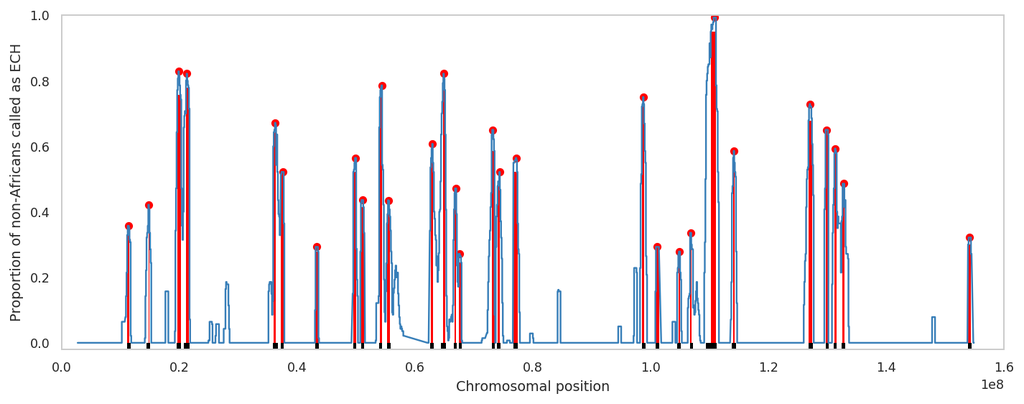

```python
with sns.color_palette([set1['blue']]):
    with sns.axes_style("whitegrid", {'axes.grid' : False}):
        fig, ax = plt.subplots(figsize=(10, 4))

        x = [j for i in zip(non_afr_total_swept.start, non_afr_total_swept.end) for j in i]
        y = [j for i in zip(non_afr_total_swept.prop_swept, non_afr_total_swept.prop_swept) for j in i]
        g = ax.plot(x, y)
        g = ax.scatter(sweep_peaks.pos, sweep_peaks.prop_swept, c='red')

        for tup in extended_peak_regions_90.itertuples():
            g = ax.add_patch(Rectangle((tup.start_pos, 0), tup.end_pos-tup.start_pos, tup.prop_swept,
                         facecolor='red',
                         linewidth=0,
                         alpha=1.0,
                         zorder=1))

        for tup in extended_peak_regions_75.itertuples():
            g = ax.add_patch(Rectangle((tup.start_pos, -0.02), tup.end_pos-tup.start_pos, 0.02,
                         facecolor='black',
                         linewidth=0,
                         alpha=1.0,
                         zorder=1))

        ax.set_ylim(-0.02,1)
        ax.set_xlim(0,160e6)

        ax.set_ylabel('Proportion of non-Africans called as ECH')
        ax.set_xlabel('Chromosomal position')

        plt.tight_layout()

        plt.savefig(str(figures_dir / 'tot_swept_ext_regions.pdf'))

#mpld3.display(fig)
```

```python
(extended_peak_regions_90
 .assign(prop_swept_across=lambda df: [len(eval(x))/140 for x in df.swept_indivs])
 .assign(length=lambda df: df.end_pos-df.start_pos)
 .drop('swept_indivs', axis=1)
 .sort_values('length', ascending=False)
)
```

|  | pos | peak_start | peak_end | peak_prop_swept | start_pos | end_pos | prop_swept | prop_swept_across | length |
| --- | --- | --- | --- | --- | --- | --- | --- | --- | --- |
| 22 | 110900000.0 | 110700000 | 111100000 | 0.992857 | 110200000 | 111100000 | 0.950000 | 0.914286 | 900000 |
| 17 | 77150000.0 | 77100000 | 77200000 | 0.564286 | 76700000 | 77400000 | 0.521429 | 0.507143 | 700000 |
| 2 | 19850000.0 | 19800000 | 19900000 | 0.828571 | 19600000 | 20200000 | 0.757143 | 0.671429 | 600000 |
| 24 | 127050000.0 | 127000000 | 127100000 | 0.728571 | 126800000 | 127400000 | 0.678571 | 0.600000 | 600000 |
| 14 | 67500000.0 | 67400000 | 67600000 | 0.271429 | 67400000 | 67900000 | 0.244604 | 0.242857 | 500000 |
| 15 | 73200000.0 | 73100000 | 73300000 | 0.650000 | 73000000 | 73500000 | 0.585714 | 0.578571 | 500000 |
| 25 | 129900000.0 | 129700000 | 130100000 | 0.650000 | 129700000 | 130200000 | 0.635714 | 0.635714 | 500000 |
| 19 | 101150000.0 | 100900000 | 101400000 | 0.292857 | 100900000 | 101400000 | 0.292857 | 0.292857 | 500000 |
| 28 | 154200000.0 | 154000000 | 154400000 | 0.321429 | 153900000 | 154400000 | 0.300000 | 0.300000 | 500000 |
| 6 | 43300000.0 | 43100000 | 43500000 | 0.292857 | 43100000 | 43600000 | 0.278571 | 0.278571 | 500000 |
| 3 | 21250000.0 | 21200000 | 21300000 | 0.821429 | 21100000 | 21600000 | 0.778571 | 0.735714 | 500000 |
| 5 | 37500000.0 | 37300000 | 37700000 | 0.521429 | 37200000 | 37700000 | 0.514286 | 0.514286 | 500000 |
| 8 | 51050000.0 | 50900000 | 51200000 | 0.435714 | 50800000 | 51300000 | 0.414286 | 0.407143 | 500000 |
| 7 | 49900000.0 | 49800000 | 50000000 | 0.564286 | 49500000 | 50000000 | 0.521429 | 0.521429 | 500000 |
| 18 | 98750000.0 | 98700000 | 98800000 | 0.750000 | 98500000 | 98900000 | 0.721429 | 0.685714 | 400000 |
| 26 | 131350000.0 | 131300000 | 131400000 | 0.592857 | 131200000 | 131600000 | 0.578571 | 0.564286 | 400000 |
| 4 | 36250000.0 | 36200000 | 36300000 | 0.671429 | 36000000 | 36400000 | 0.642857 | 0.628571 | 400000 |
| 10 | 55450000.0 | 55400000 | 55500000 | 0.435115 | 55300000 | 55700000 | 0.392857 | 0.328571 | 400000 |
| 9 | 54350000.0 | 54300000 | 54400000 | 0.785714 | 54000000 | 54400000 | 0.750000 | 0.750000 | 400000 |
| 16 | 74350000.0 | 74300000 | 74400000 | 0.521429 | 74000000 | 74400000 | 0.478571 | 0.457143 | 400000 |
| 12 | 64850000.0 | 64800000 | 64900000 | 0.821429 | 64700000 | 65100000 | 0.771429 | 0.750000 | 400000 |
| 11 | 62950000.0 | 62900000 | 63000000 | 0.607143 | 62700000 | 63100000 | 0.550000 | 0.507143 | 400000 |
| 0 | 11300000.0 | 11200000 | 11400000 | 0.357143 | 11100000 | 11500000 | 0.328571 | 0.321429 | 400000 |
| 20 | 104900000.0 | 104800000 | 105000000 | 0.278571 | 104700000 | 105000000 | 0.270073 | 0.271429 | 300000 |
| 23 | 114150000.0 | 114100000 | 114200000 | 0.585714 | 114000000 | 114300000 | 0.550000 | 0.521429 | 300000 |
| 13 | 66900000.0 | 66800000 | 67000000 | 0.471429 | 66700000 | 67000000 | 0.457143 | 0.450000 | 300000 |
| 27 | 132750000.0 | 132600000 | 132900000 | 0.485714 | 132600000 | 132900000 | 0.485714 | 0.485714 | 300000 |
| 21 | 106800000.0 | 106700000 | 106900000 | 0.335714 | 106700000 | 106900000 | 0.335714 | 0.321429 | 200000 |
| 1 | 14750000.0 | 14700000 | 14800000 | 0.421429 | 14700000 | 14900000 | 0.407143 | 0.407143 | 200000 |

```python
(extended_peak_regions_75
 .assign(prop_swept_across=lambda df: [len(eval(x))/140 for x in df.swept_indivs])
 .assign(length=lambda df: df.end_pos-df.start_pos)
 .drop('swept_indivs', axis=1)
 .sort_values('length', ascending=False)
)
```

|  | pos | peak_start | peak_end | peak_prop_swept | start_pos | end_pos | prop_swept | prop_swept_across | length |
| --- | --- | --- | --- | --- | --- | --- | --- | --- | --- |
| 22 | 110900000.0 | 110700000 | 111100000 | 0.992857 | 109400000 | 111200000 | 0.757143 | 0.528571 | 1800000 |
| 3 | 21250000.0 | 21200000 | 21300000 | 0.821429 | 20700000 | 21700000 | 0.657143 | 0.528571 | 1000000 |
| 2 | 19850000.0 | 19800000 | 19900000 | 0.828571 | 19500000 | 20300000 | 0.642857 | 0.535714 | 800000 |
| 4 | 36250000.0 | 36200000 | 36300000 | 0.671429 | 35900000 | 36700000 | 0.521429 | 0.314286 | 800000 |
| 12 | 64850000.0 | 64800000 | 64900000 | 0.821429 | 64400000 | 65200000 | 0.635714 | 0.435714 | 800000 |
| 27 | 132750000.0 | 132600000 | 132900000 | 0.485714 | 132400000 | 133100000 | 0.371429 | 0.257143 | 700000 |
| 24 | 127050000.0 | 127000000 | 127100000 | 0.728571 | 126800000 | 127500000 | 0.607143 | 0.521429 | 700000 |
| 23 | 114150000.0 | 114100000 | 114200000 | 0.585714 | 113800000 | 114500000 | 0.457143 | 0.371429 | 700000 |
| 10 | 55450000.0 | 55400000 | 55500000 | 0.435115 | 55200000 | 55900000 | 0.342857 | 0.200000 | 700000 |
| 17 | 77150000.0 | 77100000 | 77200000 | 0.564286 | 76700000 | 77400000 | 0.521429 | 0.507143 | 700000 |
| 0 | 11300000.0 | 11200000 | 11400000 | 0.357143 | 11100000 | 11700000 | 0.307143 | 0.278571 | 600000 |
| 16 | 74350000.0 | 74300000 | 74400000 | 0.521429 | 73900000 | 74500000 | 0.421429 | 0.342857 | 600000 |
| 20 | 104900000.0 | 104800000 | 105000000 | 0.278571 | 104500000 | 105100000 | 0.214286 | 0.150000 | 600000 |
| 18 | 98750000.0 | 98700000 | 98800000 | 0.750000 | 98500000 | 99100000 | 0.585714 | 0.535714 | 600000 |
| 28 | 154200000.0 | 154000000 | 154400000 | 0.321429 | 153900000 | 154500000 | 0.271429 | 0.250000 | 600000 |
| 1 | 14750000.0 | 14700000 | 14800000 | 0.421429 | 14400000 | 15000000 | 0.321429 | 0.221429 | 600000 |
| 11 | 62950000.0 | 62900000 | 63000000 | 0.607143 | 62600000 | 63200000 | 0.521429 | 0.371429 | 600000 |
| 8 | 51050000.0 | 50900000 | 51200000 | 0.435714 | 50800000 | 51400000 | 0.335714 | 0.328571 | 600000 |
| 15 | 73200000.0 | 73100000 | 73300000 | 0.650000 | 73000000 | 73500000 | 0.585714 | 0.578571 | 500000 |
| 13 | 66900000.0 | 66800000 | 67000000 | 0.471429 | 66600000 | 67100000 | 0.392857 | 0.321429 | 500000 |
| 19 | 101150000.0 | 100900000 | 101400000 | 0.292857 | 100900000 | 101400000 | 0.292857 | 0.292857 | 500000 |
| 9 | 54350000.0 | 54300000 | 54400000 | 0.785714 | 53900000 | 54400000 | 0.657143 | 0.657143 | 500000 |
| 21 | 106800000.0 | 106700000 | 106900000 | 0.335714 | 106700000 | 107200000 | 0.285714 | 0.250000 | 500000 |
| 7 | 49900000.0 | 49800000 | 50000000 | 0.564286 | 49500000 | 50000000 | 0.521429 | 0.521429 | 500000 |
| 6 | 43300000.0 | 43100000 | 43500000 | 0.292857 | 43100000 | 43600000 | 0.278571 | 0.278571 | 500000 |
| 25 | 129900000.0 | 129700000 | 130100000 | 0.650000 | 129700000 | 130200000 | 0.635714 | 0.635714 | 500000 |
| 26 | 131350000.0 | 131300000 | 131400000 | 0.592857 | 131100000 | 131600000 | 0.471429 | 0.457143 | 500000 |
| 5 | 37500000.0 | 37300000 | 37700000 | 0.521429 | 37200000 | 37700000 | 0.514286 | 0.514286 | 500000 |
| 14 | 67500000.0 | 67400000 | 67600000 | 0.271429 | 67400000 | 67900000 | 0.244604 | 0.242857 | 500000 |

```python
(extended_peak_regions_10
 .assign(prop_swept_across=lambda df: [len(eval(x))/140 for x in df.swept_indivs])
 .assign(length=lambda df: df.end_pos-df.start_pos)
 .drop('swept_indivs', axis=1)
 .sort_values('length', ascending=False)
)
```

|  | pos | peak_start | peak_end | peak_prop_swept | start_pos | end_pos | prop_swept | prop_swept_across | length |
| --- | --- | --- | --- | --- | --- | --- | --- | --- | --- |
| 22 | 110900000.0 | 110700000 | 111100000 | 0.992857 | 109100000 | 111600000 | 0.214286 | 0.114286 | 2500000 |
| 24 | 127050000.0 | 127000000 | 127100000 | 0.728571 | 126000000 | 127700000 | 0.115942 | 0.050000 | 1700000 |
| 9 | 54350000.0 | 54300000 | 54400000 | 0.785714 | 53400000 | 54900000 | 0.092857 | 0.000000 | 1500000 |
| 0 | 11300000.0 | 11200000 | 11400000 | 0.357143 | 10200000 | 11700000 | 0.064286 | 0.000000 | 1500000 |
| 12 | 64850000.0 | 64800000 | 64900000 | 0.821429 | 63800000 | 65300000 | 0.185714 | 0.035714 | 1500000 |
| 11 | 62950000.0 | 62900000 | 63000000 | 0.607143 | 62500000 | 63900000 | 0.185714 | 0.007143 | 1400000 |
| 15 | 73200000.0 | 73100000 | 73300000 | 0.650000 | 72300000 | 73600000 | 0.085714 | 0.000000 | 1300000 |
| 27 | 132750000.0 | 132600000 | 132900000 | 0.485714 | 132300000 | 133600000 | 0.214286 | 0.021429 | 1300000 |
| 2 | 19850000.0 | 19800000 | 19900000 | 0.828571 | 19300000 | 20600000 | 0.314286 | 0.021429 | 1300000 |
| 10 | 55450000.0 | 55400000 | 55500000 | 0.435115 | 55000000 | 56300000 | 0.085714 | 0.000000 | 1300000 |
| 21 | 106800000.0 | 106700000 | 106900000 | 0.335714 | 106300000 | 107500000 | 0.085714 | 0.000000 | 1200000 |
| 18 | 98750000.0 | 98700000 | 98800000 | 0.750000 | 98200000 | 99400000 | 0.207143 | 0.050000 | 1200000 |
| 16 | 74350000.0 | 74300000 | 74400000 | 0.521429 | 73700000 | 74900000 | 0.121429 | 0.064286 | 1200000 |
| 4 | 36250000.0 | 36200000 | 36300000 | 0.671429 | 35900000 | 37100000 | 0.328467 | 0.164286 | 1200000 |
| 3 | 21250000.0 | 21200000 | 21300000 | 0.821429 | 20500000 | 21700000 | 0.314286 | 0.257143 | 1200000 |
| 17 | 77150000.0 | 77100000 | 77200000 | 0.564286 | 76700000 | 77800000 | 0.092857 | 0.092857 | 1100000 |
| 23 | 114150000.0 | 114100000 | 114200000 | 0.585714 | 113600000 | 114700000 | 0.071429 | 0.021429 | 1100000 |
| 1 | 14750000.0 | 14700000 | 14800000 | 0.421429 | 14200000 | 15200000 | 0.142857 | 0.071429 | 1000000 |
| 13 | 66900000.0 | 66800000 | 67000000 | 0.471429 | 66500000 | 67400000 | 0.171429 | 0.028571 | 900000 |
| 7 | 49900000.0 | 49800000 | 50000000 | 0.564286 | 49400000 | 50300000 | 0.142857 | 0.021429 | 900000 |
| 5 | 37500000.0 | 37300000 | 37700000 | 0.521429 | 37000000 | 37800000 | 0.328467 | 0.000000 | 800000 |
| 26 | 131350000.0 | 131300000 | 131400000 | 0.592857 | 131000000 | 131800000 | 0.350000 | 0.207143 | 800000 |
| 20 | 104900000.0 | 104800000 | 105000000 | 0.278571 | 104500000 | 105300000 | 0.035714 | 0.028571 | 800000 |
| 25 | 129900000.0 | 129700000 | 130100000 | 0.650000 | 129500000 | 130200000 | 0.407143 | 0.400000 | 700000 |
| 8 | 51050000.0 | 50900000 | 51200000 | 0.435714 | 50700000 | 51400000 | 0.278571 | 0.214286 | 700000 |
| 14 | 67500000.0 | 67400000 | 67600000 | 0.271429 | 67300000 | 67900000 | 0.171429 | 0.100000 | 600000 |
| 19 | 101150000.0 | 100900000 | 101400000 | 0.292857 | 100800000 | 101400000 | 0.157143 | 0.157143 | 600000 |
| 6 | 43300000.0 | 43100000 | 43500000 | 0.292857 | 43000000 | 43600000 | 0.100000 | 0.085714 | 600000 |
| 28 | 154200000.0 | 154000000 | 154400000 | 0.321429 | 153900000 | 154500000 | 0.271429 | 0.250000 | 600000 |

```python
extended_peak_regions_10 = pandas.read_hdf(results_dir / 'extended_peak_regions_10%.hdf')
(extended_peak_regions_10
 .drop('swept_indivs', axis=1)
 .sort_values(by='pos')
 .assign(prop_swept=lambda df: df.prop_swept.round(2),
        pos=lambda df: df.pos.astype(int))
 .to_csv(results_dir / 'extended_peak_regions_10%.csv', index=False)
)
```

```python
renaming = {'peak_start': 'peak start', 'peak_prop_swept': 'peak prop swept', 'peak_end': 'peak end',
            'start_pos': 'start', 'end_pos': 'end',
            'prop_swept': 'Min freq. ECH', 'prop_swept_across': 'Freq. ECHs spanning region'}

df = ((extended_peak_regions_75
       .assign(prop_swept=lambda df: df.prop_swept.round(2),
               prop_swept_across=lambda df: [round(len(eval(x))/140, 2) for x in df.swept_indivs],
               length=lambda df: df.end_pos - df.start_pos)
       .drop(['pos', 'swept_indivs'], axis=1)
      ).rename(columns=renaming)
      .merge((extended_peak_regions_90
             .assign(prop_swept=lambda df: df.prop_swept.round(2),
                     prop_swept_across=lambda df: [round(len(eval(x))/140, 2) for x in df.swept_indivs],
                     length=lambda df: df.end_pos - df.start_pos)
              .drop(['pos', 'swept_indivs'], axis=1)
             ).rename(columns=renaming),
             on=['peak start', 'peak end', 'peak prop swept'],
             suffixes=(' (75%)', ' (90%)'))
     .sort_values(by='peak start')
     )

#df.to_csv(results_dir / 'ech_regions_som.csv', index=False)
df
```

|  | peak start | peak end | peak prop swept | start (75%) | end (75%) | Min freq. ECH (75%) | Freq. ECHs spanning region (75%) | length (75%) | start (90%) | end (90%) | Min freq. ECH (90%) | Freq. ECHs spanning region (90%) | length (90%) |
| --- | --- | --- | --- | --- | --- | --- | --- | --- | --- | --- | --- | --- | --- |
| 0 | 11200000 | 11400000 | 0.357143 | 11100000 | 11700000 | 0.31 | 0.28 | 600000 | 11100000 | 11500000 | 0.33 | 0.32 | 400000 |
| 1 | 14700000 | 14800000 | 0.421429 | 14400000 | 15000000 | 0.32 | 0.22 | 600000 | 14700000 | 14900000 | 0.41 | 0.41 | 200000 |
| 2 | 19800000 | 19900000 | 0.828571 | 19500000 | 20300000 | 0.64 | 0.54 | 800000 | 19600000 | 20200000 | 0.76 | 0.67 | 600000 |
| 3 | 21200000 | 21300000 | 0.821429 | 20700000 | 21700000 | 0.66 | 0.53 | 1000000 | 21100000 | 21600000 | 0.78 | 0.74 | 500000 |
| 4 | 36200000 | 36300000 | 0.671429 | 35900000 | 36700000 | 0.52 | 0.31 | 800000 | 36000000 | 36400000 | 0.64 | 0.63 | 400000 |
| 5 | 37300000 | 37700000 | 0.521429 | 37200000 | 37700000 | 0.51 | 0.51 | 500000 | 37200000 | 37700000 | 0.51 | 0.51 | 500000 |
| 6 | 43100000 | 43500000 | 0.292857 | 43100000 | 43600000 | 0.28 | 0.28 | 500000 | 43100000 | 43600000 | 0.28 | 0.28 | 500000 |
| 7 | 49800000 | 50000000 | 0.564286 | 49500000 | 50000000 | 0.52 | 0.52 | 500000 | 49500000 | 50000000 | 0.52 | 0.52 | 500000 |
| 8 | 50900000 | 51200000 | 0.435714 | 50800000 | 51400000 | 0.34 | 0.33 | 600000 | 50800000 | 51300000 | 0.41 | 0.41 | 500000 |
| 9 | 54300000 | 54400000 | 0.785714 | 53900000 | 54400000 | 0.66 | 0.66 | 500000 | 54000000 | 54400000 | 0.75 | 0.75 | 400000 |
| 10 | 55400000 | 55500000 | 0.435115 | 55200000 | 55900000 | 0.34 | 0.20 | 700000 | 55300000 | 55700000 | 0.39 | 0.33 | 400000 |
| 11 | 62900000 | 63000000 | 0.607143 | 62600000 | 63200000 | 0.52 | 0.37 | 600000 | 62700000 | 63100000 | 0.55 | 0.51 | 400000 |
| 12 | 64800000 | 64900000 | 0.821429 | 64400000 | 65200000 | 0.64 | 0.44 | 800000 | 64700000 | 65100000 | 0.77 | 0.75 | 400000 |
| 13 | 66800000 | 67000000 | 0.471429 | 66600000 | 67100000 | 0.39 | 0.32 | 500000 | 66700000 | 67000000 | 0.46 | 0.45 | 300000 |
| 14 | 67400000 | 67600000 | 0.271429 | 67400000 | 67900000 | 0.24 | 0.24 | 500000 | 67400000 | 67900000 | 0.24 | 0.24 | 500000 |
| 15 | 73100000 | 73300000 | 0.650000 | 73000000 | 73500000 | 0.59 | 0.58 | 500000 | 73000000 | 73500000 | 0.59 | 0.58 | 500000 |
| 16 | 74300000 | 74400000 | 0.521429 | 73900000 | 74500000 | 0.42 | 0.34 | 600000 | 74000000 | 74400000 | 0.48 | 0.46 | 400000 |
| 17 | 77100000 | 77200000 | 0.564286 | 76700000 | 77400000 | 0.52 | 0.51 | 700000 | 76700000 | 77400000 | 0.52 | 0.51 | 700000 |
| 18 | 98700000 | 98800000 | 0.750000 | 98500000 | 99100000 | 0.59 | 0.54 | 600000 | 98500000 | 98900000 | 0.72 | 0.69 | 400000 |
| 19 | 100900000 | 101400000 | 0.292857 | 100900000 | 101400000 | 0.29 | 0.29 | 500000 | 100900000 | 101400000 | 0.29 | 0.29 | 500000 |
| 20 | 104800000 | 105000000 | 0.278571 | 104500000 | 105100000 | 0.21 | 0.15 | 600000 | 104700000 | 105000000 | 0.27 | 0.27 | 300000 |
| 21 | 106700000 | 106900000 | 0.335714 | 106700000 | 107200000 | 0.29 | 0.25 | 500000 | 106700000 | 106900000 | 0.34 | 0.32 | 200000 |
| 22 | 110700000 | 111100000 | 0.992857 | 109400000 | 111200000 | 0.76 | 0.53 | 1800000 | 110200000 | 111100000 | 0.95 | 0.91 | 900000 |
| 23 | 114100000 | 114200000 | 0.585714 | 113800000 | 114500000 | 0.46 | 0.37 | 700000 | 114000000 | 114300000 | 0.55 | 0.52 | 300000 |
| 24 | 127000000 | 127100000 | 0.728571 | 126800000 | 127500000 | 0.61 | 0.52 | 700000 | 126800000 | 127400000 | 0.68 | 0.60 | 600000 |
| 25 | 129700000 | 130100000 | 0.650000 | 129700000 | 130200000 | 0.64 | 0.64 | 500000 | 129700000 | 130200000 | 0.64 | 0.64 | 500000 |
| 26 | 131300000 | 131400000 | 0.592857 | 131100000 | 131600000 | 0.47 | 0.46 | 500000 | 131200000 | 131600000 | 0.58 | 0.56 | 400000 |
| 27 | 132600000 | 132900000 | 0.485714 | 132400000 | 133100000 | 0.37 | 0.26 | 700000 | 132600000 | 132900000 | 0.49 | 0.49 | 300000 |
| 28 | 154000000 | 154400000 | 0.321429 | 153900000 | 154500000 | 0.27 | 0.25 | 600000 | 153900000 | 154400000 | 0.30 | 0.30 | 500000 |

## Table for supplementary

```python
df = (((sweep_peaks[['pos', 'start', 'end', 'prop_swept']]
        .merge(extended_peak_regions_90, suffixes=('_peak', ''),
               left_on=['pos', 'start', 'end'], right_on=['pos', 'peak_start', 'peak_end'])
       ).drop(['start', 'end'], axis=1)
        .assign(prop_swept_peak=lambda df: [round(x, 2) for x in df.prop_swept_peak] )

       .assign(prop_swept=lambda df: df.prop_swept.round(2),
               prop_swept_across=lambda df: [round(len(eval(x))/140, 2) for x in df.swept_indivs],
               peak_start = lambda df: (df.peak_start / 100000).astype('int'),
               peak_end = lambda df: (df.peak_end / 100000).astype('int'),
               start_pos=lambda df: (df.start_pos / 100000).astype('int'),
               end_pos=lambda df: (df.end_pos / 100000).astype('int'))
       .assign(length=lambda df: df.end_pos - df.start_pos)
       .drop(['swept_indivs'], axis=1)
      )[['pos', 'peak_start', 'peak_end', 'prop_swept_peak', 'start_pos', 'end_pos', 'length', 'prop_swept', 'prop_swept_across']]
      .merge((extended_peak_regions_75
             .assign(prop_swept=lambda df: df.prop_swept.round(2),
                     prop_swept_across=lambda df: [round(len(eval(x))/140, 2) for x in df.swept_indivs],
                     peak_start = lambda df: (df.peak_start / 100000).astype('int'),
                     peak_end = lambda df: (df.peak_end / 100000).astype('int'),
                     start_pos=lambda df: (df.start_pos / 100000).astype('int'),
                     end_pos=lambda df: (df.end_pos / 100000).astype('int'))
              .assign(length=lambda df: df.end_pos - df.start_pos)
              .drop(['swept_indivs'], axis=1)
             )[['pos', 'peak_start', 'peak_end', 'start_pos', 'end_pos', 'length', 'prop_swept', 'prop_swept_across']],
             on=['pos', 'peak_start', 'peak_end'],
             suffixes=(' (90%)', ' (75%)'))
     .sort_values(by=['peak_start'])
     )

df.columns = pandas.MultiIndex(levels=[['Peak', '90%-region', '75%-region'],
                                       ['pos', 'Start', 'End', 'Freq. ECH', 'Length', 'Min freq. ECH', 'Freq. ECHs spanning region']],
                               labels=[[0, 0, 0, 0, 1, 1, 1, 1, 1, 2, 2, 2, 2, 2],
                                       [0, 1, 2, 3, 1, 2, 4, 5, 6, 1, 2, 4, 5, 6]])
df = df.drop(('Peak', 'pos'), axis=1)

df[('Data S1', 'Subplot')] = list('ABCDEFGHIJKLMNOPQRSTUVWXYZ$%&#@*'[:len(df)])

df.to_csv(results_dir / 'ech_regions_som_multidx.csv', index=False)
df
```

|  | Peak Start | Peak End | Peak Freq. ECH | 90%-region Start | 90%-region End | 90%-region Length | 90%-region Min freq. ECH | 90%-region Freq. ECHs spanning region | 75%-region Start | 75%-region End | 75%-region Length | 75%-region Min freq. ECH | 75%-region Freq. ECHs spanning region | Data S1 Subplot |
| --- | --- | --- | --- | --- | --- | --- | --- | --- | --- | --- | --- | --- | --- | --- |
| 0 | 112 | 114 | 0.36 | 111 | 115 | 4 | 0.33 | 0.32 | 111 | 117 | 6 | 0.31 | 0.28 | A |
| 1 | 147 | 148 | 0.42 | 147 | 149 | 2 | 0.41 | 0.41 | 144 | 150 | 6 | 0.32 | 0.22 | B |
| 2 | 198 | 199 | 0.83 | 196 | 202 | 6 | 0.76 | 0.67 | 195 | 203 | 8 | 0.64 | 0.54 | C |
| 3 | 212 | 213 | 0.82 | 211 | 216 | 5 | 0.78 | 0.74 | 207 | 217 | 10 | 0.66 | 0.53 | D |
| 4 | 362 | 363 | 0.67 | 360 | 364 | 4 | 0.64 | 0.63 | 359 | 367 | 8 | 0.52 | 0.31 | E |
| 5 | 373 | 377 | 0.52 | 372 | 377 | 5 | 0.51 | 0.51 | 372 | 377 | 5 | 0.51 | 0.51 | F |
| 6 | 431 | 435 | 0.29 | 431 | 436 | 5 | 0.28 | 0.28 | 431 | 436 | 5 | 0.28 | 0.28 | G |
| 7 | 498 | 500 | 0.56 | 495 | 500 | 5 | 0.52 | 0.52 | 495 | 500 | 5 | 0.52 | 0.52 | H |
| 8 | 509 | 512 | 0.44 | 508 | 513 | 5 | 0.41 | 0.41 | 508 | 514 | 6 | 0.34 | 0.33 | I |
| 9 | 543 | 544 | 0.79 | 540 | 544 | 4 | 0.75 | 0.75 | 539 | 544 | 5 | 0.66 | 0.66 | J |
| 10 | 554 | 555 | 0.44 | 553 | 557 | 4 | 0.39 | 0.33 | 552 | 559 | 7 | 0.34 | 0.20 | K |
| 11 | 629 | 630 | 0.61 | 627 | 631 | 4 | 0.55 | 0.51 | 626 | 632 | 6 | 0.52 | 0.37 | L |
| 12 | 648 | 649 | 0.82 | 647 | 651 | 4 | 0.77 | 0.75 | 644 | 652 | 8 | 0.64 | 0.44 | M |
| 13 | 668 | 670 | 0.47 | 667 | 670 | 3 | 0.46 | 0.45 | 666 | 671 | 5 | 0.39 | 0.32 | N |
| 14 | 674 | 676 | 0.27 | 674 | 679 | 5 | 0.24 | 0.24 | 674 | 679 | 5 | 0.24 | 0.24 | O |
| 15 | 731 | 733 | 0.65 | 730 | 735 | 5 | 0.59 | 0.58 | 730 | 735 | 5 | 0.59 | 0.58 | P |
| 16 | 743 | 744 | 0.52 | 740 | 744 | 4 | 0.48 | 0.46 | 739 | 745 | 6 | 0.42 | 0.34 | Q |
| 17 | 771 | 772 | 0.56 | 767 | 774 | 7 | 0.52 | 0.51 | 767 | 774 | 7 | 0.52 | 0.51 | R |
| 18 | 987 | 988 | 0.75 | 985 | 989 | 4 | 0.72 | 0.69 | 985 | 991 | 6 | 0.59 | 0.54 | S |
| 19 | 1009 | 1014 | 0.29 | 1009 | 1014 | 5 | 0.29 | 0.29 | 1009 | 1014 | 5 | 0.29 | 0.29 | T |
| 20 | 1048 | 1050 | 0.28 | 1047 | 1050 | 3 | 0.27 | 0.27 | 1045 | 1051 | 6 | 0.21 | 0.15 | U |
| 21 | 1067 | 1069 | 0.34 | 1067 | 1069 | 2 | 0.34 | 0.32 | 1067 | 1072 | 5 | 0.29 | 0.25 | V |
| 22 | 1107 | 1111 | 0.99 | 1102 | 1111 | 9 | 0.95 | 0.91 | 1094 | 1112 | 18 | 0.76 | 0.53 | W |
| 23 | 1141 | 1142 | 0.59 | 1140 | 1143 | 3 | 0.55 | 0.52 | 1138 | 1145 | 7 | 0.46 | 0.37 | X |
| 24 | 1270 | 1271 | 0.73 | 1268 | 1274 | 6 | 0.68 | 0.60 | 1268 | 1275 | 7 | 0.61 | 0.52 | Y |
| 25 | 1297 | 1301 | 0.65 | 1297 | 1302 | 5 | 0.64 | 0.64 | 1297 | 1302 | 5 | 0.64 | 0.64 | Z |
| 26 | 1313 | 1314 | 0.59 | 1312 | 1316 | 4 | 0.58 | 0.56 | 1311 | 1316 | 5 | 0.47 | 0.46 | $ |
| 27 | 1326 | 1329 | 0.49 | 1326 | 1329 | 3 | 0.49 | 0.49 | 1324 | 1331 | 7 | 0.37 | 0.26 | % |
| 28 | 1540 | 1544 | 0.32 | 1539 | 1544 | 5 | 0.30 | 0.30 | 1539 | 1545 | 6 | 0.27 | 0.25 | & |

## relative TMRCA_half in extended regions

We use the 90% set for this and only regions with enough individuals swept that we call them as sweeps.

```python
tmrca_stats_world = pandas.read_hdf(results_dir / 'pruned_tmrca_stats.hdf')
tmrca_stats_world.head()
```

|  | start | end | chain | MCMC_sample | coal_half | tmrca | tmrca_half | rel_tmrca_half |
| --- | --- | --- | --- | --- | --- | --- | --- | --- |
| 0 | 0 | 100000 | 1.5 | 2750.0 | 226.957517 | 45083.337393 | 12645.212660 | 0.281658 |
| 1 | 100000 | 200000 | 1.5 | 2750.0 | 362.848331 | 47935.198573 | 14351.381341 | 0.300756 |
| 2 | 200000 | 300000 | 1.5 | 2750.0 | 551.114128 | 53009.238578 | 19172.584913 | 0.363367 |
| 3 | 300000 | 400000 | 1.5 | 2750.0 | 495.469935 | 50038.851797 | 14837.471573 | 0.297887 |
| 4 | 400000 | 500000 | 1.5 | 2750.0 | 513.143674 | 50557.752598 | 18956.576133 | 0.376540 |

```python
extended_peak_regions_90.loc[lambda df: df.peak_prop_swept >= analysis_globals.min_prop_swept]
```

|  | pos | peak_start | peak_end | peak_prop_swept | start_pos | end_pos | prop_swept | swept_indivs |
| --- | --- | --- | --- | --- | --- | --- | --- | --- |
| 2 | 19850000.0 | 19800000 | 19900000 | 0.828571 | 19600000 | 20200000 | 0.757143 | ['B_Australian-4', 'B_Crete-2', 'B_Dai-4', 'B_... |
| 3 | 21250000.0 | 21200000 | 21300000 | 0.821429 | 21100000 | 21600000 | 0.778571 | ['B_Australian-4', 'B_Crete-2', 'B_French-3', ... |
| 4 | 36250000.0 | 36200000 | 36300000 | 0.671429 | 36000000 | 36400000 | 0.642857 | ['B_Crete-2', 'B_Dai-4', 'B_French-3', 'B_Han-... |
| 5 | 37500000.0 | 37300000 | 37700000 | 0.521429 | 37200000 | 37700000 | 0.514286 | ['B_Crete-2', 'B_Dai-4', 'B_Han-3', 'B_Karitia... |
| 7 | 49900000.0 | 49800000 | 50000000 | 0.564286 | 49500000 | 50000000 | 0.521429 | ['B_Australian-4', 'B_French-3', 'B_Papuan-15'... |
| 9 | 54350000.0 | 54300000 | 54400000 | 0.785714 | 54000000 | 54400000 | 0.750000 | ['B_Australian-4', 'B_Crete-2', 'B_Dai-4', 'B_... |
| 11 | 62950000.0 | 62900000 | 63000000 | 0.607143 | 62700000 | 63100000 | 0.550000 | ['B_Crete-2', 'B_Dai-4', 'S_Adygei-1', 'S_Aleu... |
| 12 | 64850000.0 | 64800000 | 64900000 | 0.821429 | 64700000 | 65100000 | 0.771429 | ['B_Crete-2', 'B_Dai-4', 'B_French-3', 'B_Han-... |
| 15 | 73200000.0 | 73100000 | 73300000 | 0.650000 | 73000000 | 73500000 | 0.585714 | ['B_French-3', 'B_Han-3', 'B_Papuan-15', 'B_Sa... |
| 16 | 74350000.0 | 74300000 | 74400000 | 0.521429 | 74000000 | 74400000 | 0.478571 | ['B_Crete-2', 'B_French-3', 'B_Sardinian-3', '... |
| 17 | 77150000.0 | 77100000 | 77200000 | 0.564286 | 76700000 | 77400000 | 0.521429 | ['B_Australian-4', 'B_French-3', 'B_Sardinian-... |
| 18 | 98750000.0 | 98700000 | 98800000 | 0.750000 | 98500000 | 98900000 | 0.721429 | ['B_Dai-4', 'B_French-3', 'B_Han-3', 'B_Kariti... |
| 22 | 110900000.0 | 110700000 | 111100000 | 0.992857 | 110200000 | 111100000 | 0.950000 | ['B_Australian-4', 'B_Crete-2', 'B_Dai-4', 'B_... |
| 23 | 114150000.0 | 114100000 | 114200000 | 0.585714 | 114000000 | 114300000 | 0.550000 | ['B_Australian-4', 'B_Crete-2', 'B_Dai-4', 'B_... |
| 24 | 127050000.0 | 127000000 | 127100000 | 0.728571 | 126800000 | 127400000 | 0.678571 | ['B_Australian-4', 'B_Crete-2', 'B_Dai-4', 'B_... |
| 25 | 129900000.0 | 129700000 | 130100000 | 0.650000 | 129700000 | 130200000 | 0.635714 | ['B_Australian-4', 'B_Crete-2', 'B_Dai-4', 'B_... |
| 26 | 131350000.0 | 131300000 | 131400000 | 0.592857 | 131200000 | 131600000 | 0.578571 | ['B_Crete-2', 'B_French-3', 'B_Han-3', 'S_Abkh... |

```python
global_mean = tmrca_stats_world.rel_tmrca_half.mean()
print('global mean rel_tmrca_half:', global_mean)
```

```
global mean rel_tmrca_half: 0.15111084869573296
```

```python
def get_rel_tmrca_half(df):
    s, e = df.start_pos.iloc[0], df.end_pos.iloc[0]
    return tmrca_stats_world.loc[lambda df: (df.start >= s) & (df.end <= e)]
```

```python
sr = (extended_peak_regions_90.loc[lambda df: df.prop_swept >= 0.25]
           .groupby(['pos', 'prop_swept']).apply(get_rel_tmrca_half).reset_index()
          )['rel_tmrca_half']
print('mean rel_tmrca_half for all sweeps:', sr.mean())
print(scipy.stats.ttest_ind(tmrca_stats_world.rel_tmrca_half, sr))
```

```
mean rel_tmrca_half for all sweeps: 0.05818693924050169
Ttest_indResult(statistic=9.34314202268533, pvalue=2.8793393326909436e-20)
```

```python
sr = (extended_peak_regions_90.loc[lambda df: df.peak_prop_swept >= analysis_globals.min_prop_swept]
           .groupby(['pos', 'prop_swept']).apply(get_rel_tmrca_half).reset_index()
          )['rel_tmrca_half']
print('mean rel_tmrca_half for all sweeps:', sr.mean())
print(scipy.stats.ttest_ind(tmrca_stats_world.rel_tmrca_half, sr))
```

```
mean rel_tmrca_half for all sweeps: 0.043189934106859215
Ttest_indResult(statistic=8.947053057518552, pvalue=9.662913498502174e-19)
```

## Extract SNPs shared by all swept individuals (for David)

We use the 90% set for this and only regions with enough individuals swept that we call them as sweeps.

Load sequence indexes:

```python
file_index = dict()
for file_path in male_x_haploid_dir.glob('*.fa'):
    name = file_path.name.split('.')[0]
    file_index[name] = pyfaidx.Fasta(str(file_path),
                                     strict_bounds=True,
                                     one_based_attributes=False)

reference_index = pyfaidx.Fasta(str(reference_genome_file),
                                 strict_bounds=True,
                                 one_based_attributes=False)

def get_alignmnet(sample_ids, start, end):
    assert start < end
    start, end = int(start), int(end)
    seq_list = list()
    name_list = list()

    for sample_id in sample_ids:
        name = sample_id + '-A'
        seq_list.append(file_index[name]['X'][start:end].seq)
        name_list.append(name.replace('-A', ''))

    return name_list, seq_list
```

```python
from collections import Counter

non_afr_indivs = sweep_data.loc[lambda df: df.region_1 != 'Africa', 'indiv_1'].unique()

records = list()
for tup in extended_peak_regions_90.loc[lambda df: df.peak_prop_swept >= analysis_globals.min_prop_swept].itertuples():

    pos, start, end = tup.pos, tup.peak_start, tup.peak_end

    # sequenes in window
    names, aln = get_alignmnet(non_afr_indivs, start, end)

    # reference sequence
    ref = reference_index['X'][start:end].seq

    # get snp columns
    snp_idx = dict()
    for j in range(end-start):
        col = [aln[i][j] for i in range(len(aln))]

        if col.count('N') / len(non_afr_indivs) > 0.5:
            continue

        counter = Counter(col)

        if 'N' in counter:
            del counter['N']

        counts = counter.most_common()
        if len(counts) == 2:
            snp_idx[j] = counter

    # get snps that are fixed in swept indivs
    swept_indivs = eval(tup.swept_indivs)
    subaln = [seq for (name, seq) in zip(names, aln) if name in swept_indivs]
    for j, counter in snp_idx.items():
        try:
            col = [subaln[i][j] for i in range(len(subaln))]
        except IndexError:
            print(j, len(subaln), len(swept_indivs))
            print(names)
            print(swept_indivs)
            print
            raise

        if col.count('N') / len(swept_indivs) > 0.5:
            continue

        bases = set(col)
        if 'N' in bases:
            bases.remove('N')
        if len(bases) == 1:
            swept_base = bases.pop()
            alt_base = [b for b in counter if b != swept_base][0]
            ref_base = ref[j]
            records.append((pos, start, end,
                  j+start,
                  swept_base, counter[swept_base],
                  alt_base, counter[alt_base],
                  ref_base,
                  len(swept_indivs), len(non_afr_indivs), repr(swept_indivs)))

snps_for_david = pandas.DataFrame().from_records(records, columns=['peak_pos', 'start', 'end', 'snp_pos',
                                                  'swept_base', 'swept_base_count', 'other_base', 'other_base_count',
                                                  'ref_base', 'nr_swept_indiv', 'nr_non_afr_indiv', 'swept_indivs'])
```

```python
snps_for_david.to_hdf(results_dir / 'snps_for_david.hdf', 'df', format='table', mode='w')
snps_for_david.to_csv(results_dir / 'snps_for_david.tsv', sep='\t')
```